https://mlyons3.github.io

# Mice Protein Expression Analysis

Phil Rinaldi and Molly Lyons, CMPS 3160

### Introduction

For our project, we will investigate a dataset on mice protein expression that we found on Kaggle (https://www.kaggle.com/ruslankl/mice-protein-expression). This dataset contains information on proteins that are expressed in several conditions in mice, including when mice are treated with the drug memantine (a drug used to treat Alzheimer's disease) if they are stimulated to learn or not stimulated to learn. We want to use the data to determine the effect memantine and different types of learning have on the mice. The data contains 1080 measurements of expression per protein, for 72 mice (and each mouse had 15 measurements taken on it). The data has already been neatly categorized by the experimental conditions to which the mice were subjected and their biological traits (specifically trisomic or control gene, injected/not injected with memantine, stimulated/not stimulated to learn). We will only be looking at the control mice.

### Project and Collaboration Plan

We are currently looking at a dataset about mice protein expression (https://www.kaggle.com/ruslankl/mice-protein-expression). This dataset contains information on proteins that are expressed in several conditions in mice, including when mice are treated with the drug memantine (a drug used to treat Alzheimer's disease). We want to use the data to determine the effect memantine on the mice. Also, memantine is NMDA receptor antagonist like the drug ketamine, which is being researched as a fast-acting antidepressant, so we were thinking of finding another dataset related to depression and Alzheimer's to see if there is some correlation between NMDA receptors, Alzheimer's, and depression. It might be difficult to find datasets that have exactly what we are looking for, which would be proteins that are over or under expressed in major depression, during ketamine use, and in people with Alzheimer's disease. The Psychiatric Genomics Consortium has data on major depressive disorder, though it is unclear what form the data is in (entire genome, proteins expressed, etc.). We also must apply to download the data from the Psychiatric Genomics Consortium, which poses the risk that we might not be able to get access to the data. There is a microarray analysis on Alzheimer’s disease on Kaggle (https://www.kaggle.com/andrewgao/alzheimer-microarray-analysis), which could be of use to us if we decide to take this direction for our final tutorial. Particularly, the mice protein expression data contains 1080 measurements of expression per protein, for 72 mice. The data has already been neatly categorized by the experimental conditions to which the mice were subjected and their biological traits (trisomic or control gene, injected/not injected with memantic, etc.)

Two other datasets we found are ones pertaining to structural proteins and genes related to pancreatic cancer. (https://www.kaggle.com/shahir/protein-data-set and https://www.kaggle.com/abhiparashar/cancer-prediction, respectively. It was a bit difficult for us to formulate reasonable queries, as these are enormous sets of data and are intended for a wide range of research. Though these datasets are broad, we could look for overall trends that might help point us in a more specific direction. Additionally, it might be very difficult for a pair of undergraduates, one of whom does not study Biology, would be able to carry out any project of such magnitude without proper expertise and guidance. We are both in agreement that we want to work with a biological dataset, so even if our previously chosen datasets do not work out we are confident that we will be able to find another one that works.

We met on Zoom once to set up the github.io public page, share access to it, and establish a google doc to write up our milestone. We plan on zooming again next week, and will likely continue to meet bi-weekly for the remainder of the project. We will also establish a private github repository where we can collaborate on code.

### Data Extraction, Transform, and Loading

```python
import pandas as pd
import numpy as np
import matplotlib.pyplot as plt


#Opening data in pandas dataframe
df_proteins = pd.read_csv("./Data/Data_Cortex_Nuclear.csv")

#Setting index so all values in table are the same observational unit
#df_proteins.set_index(["Genotype", "Treatment", "Behavior", "class"], inplace=True)

df_proteins
```

|  | MouseID | DYRK1A_N | ITSN1_N | BDNF_N | NR1_N | NR2A_N | pAKT_N | pBRAF_N | pCAMKII_N | pCREB_N | ... | pCFOS_N | SYP_N | H3AcK18_N | EGR1_N | H3MeK4_N | CaNA_N | Genotype | Treatment | Behavior | class |
| --- | --- | --- | --- | --- | --- | --- | --- | --- | --- | --- | --- | --- | --- | --- | --- | --- | --- | --- | --- | --- | --- |
| 0 | 309_1 | 0.503644 | 0.747193 | 0.430175 | 2.816329 | 5.990152 | 0.218830 | 0.177565 | 2.373744 | 0.232224 | ... | 0.108336 | 0.427099 | 0.114783 | 0.131790 | 0.128186 | 1.675652 | Control | Memantine | C/S | c-CS-m |
| 1 | 309_2 | 0.514617 | 0.689064 | 0.411770 | 2.789514 | 5.685038 | 0.211636 | 0.172817 | 2.292150 | 0.226972 | ... | 0.104315 | 0.441581 | 0.111974 | 0.135103 | 0.131119 | 1.743610 | Control | Memantine | C/S | c-CS-m |
| 2 | 309_3 | 0.509183 | 0.730247 | 0.418309 | 2.687201 | 5.622059 | 0.209011 | 0.175722 | 2.283337 | 0.230247 | ... | 0.106219 | 0.435777 | 0.111883 | 0.133362 | 0.127431 | 1.926427 | Control | Memantine | C/S | c-CS-m |
| 3 | 309_4 | 0.442107 | 0.617076 | 0.358626 | 2.466947 | 4.979503 | 0.222886 | 0.176463 | 2.152301 | 0.207004 | ... | 0.111262 | 0.391691 | 0.130405 | 0.147444 | 0.146901 | 1.700563 | Control | Memantine | C/S | c-CS-m |
| 4 | 309_5 | 0.434940 | 0.617430 | 0.358802 | 2.365785 | 4.718679 | 0.213106 | 0.173627 | 2.134014 | 0.192158 | ... | 0.110694 | 0.434154 | 0.118481 | 0.140314 | 0.148380 | 1.839730 | Control | Memantine | C/S | c-CS-m |
| ... | ... | ... | ... | ... | ... | ... | ... | ... | ... | ... | ... | ... | ... | ... | ... | ... | ... | ... | ... | ... | ... |
| 1075 | J3295_11 | 0.254860 | 0.463591 | 0.254860 | 2.092082 | 2.600035 | 0.211736 | 0.171262 | 2.483740 | 0.207317 | ... | 0.183324 | 0.374088 | 0.318782 | 0.204660 | 0.328327 | 1.364823 | Ts65Dn | Saline | S/C | t-SC-s |
| 1076 | J3295_12 | 0.272198 | 0.474163 | 0.251638 | 2.161390 | 2.801492 | 0.251274 | 0.182496 | 2.512737 | 0.216339 | ... | 0.175674 | 0.375259 | 0.325639 | 0.200415 | 0.293435 | 1.364478 | Ts65Dn | Saline | S/C | t-SC-s |
| 1077 | J3295_13 | 0.228700 | 0.395179 | 0.234118 | 1.733184 | 2.220852 | 0.220665 | 0.161435 | 1.989723 | 0.185164 | ... | 0.158296 | 0.422121 | 0.321306 | 0.229193 | 0.355213 | 1.430825 | Ts65Dn | Saline | S/C | t-SC-s |
| 1078 | J3295_14 | 0.221242 | 0.412894 | 0.243974 | 1.876347 | 2.384088 | 0.208897 | 0.173623 | 2.086028 | 0.192044 | ... | 0.196296 | 0.397676 | 0.335936 | 0.251317 | 0.365353 | 1.404031 | Ts65Dn | Saline | S/C | t-SC-s |
| 1079 | J3295_15 | 0.302626 | 0.461059 | 0.256564 | 2.092790 | 2.594348 | 0.251001 | 0.191811 | 2.361816 | 0.223632 | ... | 0.187556 | 0.420347 | 0.335062 | 0.252995 | 0.365278 | 1.370999 | Ts65Dn | Saline | S/C | t-SC-s |

1080 rows × 82 columns

The dataset was in tidy form when we downloaded it, so not much ETL needed to be performed initially. All columns are named properly and are not variables, all empty values are set to NaN, each variable forms a row, all variables have their own column, and there is only one type of observational unit in the table. Otherwise, we had no challenges formatting the data since Kaggle had already done a very nice job making sure it was tidy. Downloading the data was also a very easy process and required no web scraping or tricky extraction.

Looking at the dataframe, there are 15 measurements for each mouse. For our future analysis we will be taking the mean of the 15 measurements for each mouse in each class as well as the average protein expression in a class of mice. There are 77 proteins expressed and 72 mice total.

### Exploratory Analysis

As stated above, we will begin by taking the mean of the 15 measurements of protein expression for each mouse. First, however, a bit more manipulation of the data is necessary. The MouseID column contains two bits of information -- the mouse that was experimented on, and the number of the measurement that any particular row represents (i.e. 309_1 denotes the first measurement taken on mouse 309). We split this column into two columns -- one for the mouse and one for the measurement number -- so that we could then easily group by mouse and take the average of the protein expression data over the 15 trials.

```python
# Sorting each measurement of protein expression in each mouse expression
df_proteins["Mouse"] = df_proteins["MouseID"].str.split("_", expand=True)[0]
df_proteins["Measurement#"] = df_proteins["MouseID"].str.split("_", expand=True)[1]
df_proteins.drop(columns="MouseID", inplace=True)
df_proteins = df_proteins.set_index(["Genotype", "Treatment", "Behavior", "Measurement#"])

#Displaying Dataframe
df_proteins
```

| Genotype | Treatment | Behavior | Measurement# | DYRK1A_N | ITSN1_N | BDNF_N | NR1_N | NR2A_N | pAKT_N | pBRAF_N | pCAMKII_N | pCREB_N | pELK_N | ... | BCL2_N | pS6_N | pCFOS_N | SYP_N | H3AcK18_N | EGR1_N | H3MeK4_N | CaNA_N | class | Mouse |
| --- | --- | --- | --- | --- | --- | --- | --- | --- | --- | --- | --- | --- | --- | --- | --- | --- | --- | --- | --- | --- | --- | --- | --- | --- |
| Control | Memantine | C/S | 1 | 0.503644 | 0.747193 | 0.430175 | 2.816329 | 5.990152 | 0.218830 | 0.177565 | 2.373744 | 0.232224 | 1.750936 | ... | NaN | 0.106305 | 0.108336 | 0.427099 | 0.114783 | 0.131790 | 0.128186 | 1.675652 | c-CS-m | 309 |
|  |  |  | 2 | 0.514617 | 0.689064 | 0.411770 | 2.789514 | 5.685038 | 0.211636 | 0.172817 | 2.292150 | 0.226972 | 1.596377 | ... | NaN | 0.106592 | 0.104315 | 0.441581 | 0.111974 | 0.135103 | 0.131119 | 1.743610 | c-CS-m | 309 |
|  |  |  | 3 | 0.509183 | 0.730247 | 0.418309 | 2.687201 | 5.622059 | 0.209011 | 0.175722 | 2.283337 | 0.230247 | 1.561316 | ... | NaN | 0.108303 | 0.106219 | 0.435777 | 0.111883 | 0.133362 | 0.127431 | 1.926427 | c-CS-m | 309 |
|  |  |  | 4 | 0.442107 | 0.617076 | 0.358626 | 2.466947 | 4.979503 | 0.222886 | 0.176463 | 2.152301 | 0.207004 | 1.595086 | ... | NaN | 0.103184 | 0.111262 | 0.391691 | 0.130405 | 0.147444 | 0.146901 | 1.700563 | c-CS-m | 309 |
|  |  |  | 5 | 0.434940 | 0.617430 | 0.358802 | 2.365785 | 4.718679 | 0.213106 | 0.173627 | 2.134014 | 0.192158 | 1.504230 | ... | NaN | 0.104784 | 0.110694 | 0.434154 | 0.118481 | 0.140314 | 0.148380 | 1.839730 | c-CS-m | 309 |
| ... | ... | ... | ... | ... | ... | ... | ... | ... | ... | ... | ... | ... | ... | ... | ... | ... | ... | ... | ... | ... | ... | ... | ... | ... |
| Ts65Dn | Saline | S/C | 11 | 0.254860 | 0.463591 | 0.254860 | 2.092082 | 2.600035 | 0.211736 | 0.171262 | 2.483740 | 0.207317 | 1.057971 | ... | NaN | 0.115806 | 0.183324 | 0.374088 | 0.318782 | 0.204660 | 0.328327 | 1.364823 | t-SC-s | J3295 |
|  |  |  | 12 | 0.272198 | 0.474163 | 0.251638 | 2.161390 | 2.801492 | 0.251274 | 0.182496 | 2.512737 | 0.216339 | 1.081150 | ... | NaN | 0.113614 | 0.175674 | 0.375259 | 0.325639 | 0.200415 | 0.293435 | 1.364478 | t-SC-s | J3295 |
|  |  |  | 13 | 0.228700 | 0.395179 | 0.234118 | 1.733184 | 2.220852 | 0.220665 | 0.161435 | 1.989723 | 0.185164 | 0.884342 | ... | NaN | 0.118948 | 0.158296 | 0.422121 | 0.321306 | 0.229193 | 0.355213 | 1.430825 | t-SC-s | J3295 |
|  |  |  | 14 | 0.221242 | 0.412894 | 0.243974 | 1.876347 | 2.384088 | 0.208897 | 0.173623 | 2.086028 | 0.192044 | 0.922595 | ... | NaN | 0.125295 | 0.196296 | 0.397676 | 0.335936 | 0.251317 | 0.365353 | 1.404031 | t-SC-s | J3295 |
|  |  |  | 15 | 0.302626 | 0.461059 | 0.256564 | 2.092790 | 2.594348 | 0.251001 | 0.191811 | 2.361816 | 0.223632 | 1.064085 | ... | NaN | 0.118899 | 0.187556 | 0.420347 | 0.335062 | 0.252995 | 0.365278 | 1.370999 | t-SC-s | J3295 |

1080 rows × 79 columns

```python
# Obtaining the mean protein expression for each mouse in each class
mean_expressions = df_proteins.groupby("Mouse").mean()
mean_expressions
```

| Mouse | DYRK1A_N | ITSN1_N | BDNF_N | NR1_N | NR2A_N | pAKT_N | pBRAF_N | pCAMKII_N | pCREB_N | pELK_N | ... | SHH_N | BAD_N | BCL2_N | pS6_N | pCFOS_N | SYP_N | H3AcK18_N | EGR1_N | H3MeK4_N | CaNA_N |
| --- | --- | --- | --- | --- | --- | --- | --- | --- | --- | --- | --- | --- | --- | --- | --- | --- | --- | --- | --- | --- | --- |
| 18899 | 0.428381 | 0.617834 | 0.299208 | 2.053351 | 3.461564 | 0.281945 | 0.191150 | 2.541373 | 0.210844 | 1.556977 | ... | 0.236160 | 0.192990 | 0.179952 | 0.120311 | NaN | 0.424551 | 0.207383 | NaN | 0.264955 | 1.328343 |
| 293 | 0.268072 | 0.532736 | 0.293274 | 2.278292 | 3.466264 | 0.255595 | 0.193701 | 3.825613 | 0.240396 | 1.203226 | ... | 0.204713 | 0.139175 | 0.121962 | 0.134576 | 0.110451 | 0.494021 | 0.426291 | 0.170461 | 0.297441 | 1.257729 |
| 294 | 0.318000 | 0.486584 | 0.315980 | 2.479140 | 3.838981 | 0.261231 | 0.204978 | 5.130094 | 0.223610 | 1.365092 | ... | 0.272471 | NaN | NaN | 0.133939 | 0.137972 | 0.483603 | NaN | 0.236137 | 0.230726 | 1.058736 |
| 309 | 0.421063 | 0.576510 | 0.356447 | 2.278252 | 4.354744 | 0.219549 | 0.182195 | 1.922373 | 0.196064 | 1.422933 | ... | 0.192871 | 0.151524 | NaN | 0.101042 | 0.115433 | 0.423088 | 0.136374 | 0.169300 | 0.169590 | 1.674160 |
| 311 | 0.600591 | 0.678479 | 0.334548 | 2.277561 | 4.234706 | 0.227820 | 0.184262 | 1.931669 | 0.176511 | 1.874307 | ... | 0.188092 | 0.166315 | 0.168952 | 0.105205 | NaN | 0.426774 | 0.141512 | 0.201386 | 0.200284 | 1.193285 |
| ... | ... | ... | ... | ... | ... | ... | ... | ... | ... | ... | ... | ... | ... | ... | ... | ... | ... | ... | ... | ... | ... |
| 50810E | 0.508742 | 0.748007 | 0.318928 | 2.299097 | 3.791904 | 0.209596 | 0.163295 | 2.570700 | 0.212496 | 1.386207 | ... | 0.231358 | 0.163582 | 0.134391 | 0.107420 | 0.133887 | 0.499405 | 0.183951 | 0.172079 | 0.211742 | 1.704720 |
| 50810F | 0.439384 | 0.560736 | 0.331974 | 2.224129 | 3.968663 | 0.278213 | 0.206829 | 3.747682 | 0.258409 | 1.532130 | ... | 0.194244 | NaN | NaN | 0.108895 | 0.114522 | 0.366727 | NaN | NaN | NaN | 1.455950 |
| J1291 | 0.241612 | 0.421927 | 0.291766 | 2.145327 | 2.954803 | 0.270469 | 0.186234 | 3.249092 | 0.246158 | 1.030867 | ... | 0.225712 | 0.163488 | NaN | 0.113939 | NaN | 0.334016 | 0.293926 | 0.160057 | 0.250398 | 1.355835 |
| J2292 | 0.258354 | 0.402856 | 0.363226 | 2.336278 | 4.499927 | 0.238544 | 0.180765 | 5.258103 | 0.200197 | 1.044921 | ... | 0.239638 | 0.157116 | 0.129411 | 0.131622 | 0.125829 | 0.511127 | 0.208220 | 0.192311 | 0.194597 | 1.190845 |
| J3295 | 0.304979 | 0.523868 | 0.295161 | 2.305810 | 3.289781 | 0.227490 | 0.177694 | 2.885428 | 0.221993 | 1.121794 | ... | 0.261961 | 0.179693 | NaN | 0.120545 | 0.137791 | 0.401608 | 0.303367 | 0.191950 | 0.281318 | 1.359334 |

72 rows × 77 columns

#### Explaining the Data

The data that we will be using in this project only pertains to the control mice, which are normal mice with no underlying health issues. We will not be using the Ts65Dn (down syndrome) mice in our analysis. There are several other variables including treatment and learning. A mouse can either be treated by memantine, which is a drug used to treat alzheimer's disease, or saline, which has no effect and is used as the control. Mice can also be stimulated to learn from context-shock associative learning, or not stimulated to learn from shock-context associative learning. So we will be working with 4 classes of mice:

- Control-Context Shock-Saline (c_CS_s)
- Control-Context Shock-Memantine (c_CS_m)
- Control-Shock Context-Saline (c_SC_s)
- Control-Shock Context-Memantine (c_SC_m)

In each of these 4 classes of mice, there are 77 protein whose expression level in the nuclear fraction of the cortex, is measured. The amoutn of expression is already standardized across all classes and mice.

We will begin by examining the differences in protein expression for the control mice who were stimulated to learn when given either saline or memantine. The two classes of interest are thus c-CS-s and c-CS-m.

```python
control_stim_saline = df_proteins[df_proteins["class"] == "c-CS-s"]
control_stim_mem = df_proteins[df_proteins["class"] == "c-CS-m"]
control_stim_saline
```

| Genotype | Treatment | Behavior | Measurement# | DYRK1A_N | ITSN1_N | BDNF_N | NR1_N | NR2A_N | pAKT_N | pBRAF_N | pCAMKII_N | pCREB_N | pELK_N | ... | BCL2_N | pS6_N | pCFOS_N | SYP_N | H3AcK18_N | EGR1_N | H3MeK4_N | CaNA_N | class | Mouse |
| --- | --- | --- | --- | --- | --- | --- | --- | --- | --- | --- | --- | --- | --- | --- | --- | --- | --- | --- | --- | --- | --- | --- | --- | --- |
| Control | Saline | C/S | 1 | 0.591618 | 0.814980 | 0.414980 | 2.706108 | 5.256264 | 0.260990 | 0.187249 | 4.163798 | 0.265894 | 1.665805 | ... | 0.107677 | 0.121155 | 0.096318 | 0.400048 | 0.154416 | 0.135307 | NaN | 1.399615 | c-CS-s | 3477 |
|  |  |  | 2 | 0.589807 | 0.840445 | 0.424325 | 2.803702 | 5.534373 | 0.269420 | 0.192834 | 4.284555 | 0.275985 | 1.849289 | ... | 0.108764 | 0.125333 | 0.112301 | 0.398866 | 0.163800 | 0.139480 | NaN | 1.410978 | c-CS-s | 3477 |
|  |  |  | 3 | 0.598902 | 0.886041 | 0.444760 | 2.918261 | 5.717712 | 0.290435 | 0.197162 | 4.497666 | 0.282288 | 1.998902 | ... | 0.108713 | 0.118600 | 0.109363 | 0.378731 | 0.154110 | 0.143156 | NaN | 1.332266 | c-CS-s | 3477 |
|  |  |  | 4 | 0.544844 | 0.726999 | 0.390846 | 2.521089 | 4.967323 | 0.275550 | 0.190962 | 4.576825 | 0.240209 | 1.591425 | ... | 0.109496 | 0.117714 | 0.099507 | 0.385510 | 0.177962 | 0.141927 | NaN | 1.394424 | c-CS-s | 3477 |
|  |  |  | 5 | 0.512785 | 0.730650 | 0.389176 | 2.514047 | 5.070519 | 0.271872 | 0.188625 | 4.548217 | 0.238390 | 1.689829 | ... | 0.114985 | 0.124239 | 0.114604 | 0.385776 | 0.184140 | 0.154982 | NaN | 1.366823 | c-CS-s | 3477 |
|  |  |  | ... | ... | ... | ... | ... | ... | ... | ... | ... | ... | ... | ... | ... | ... | ... | ... | ... | ... | ... | ... | ... | ... |
|  |  |  | 11 | 0.393097 | 0.506367 | 0.303954 | 2.169236 | 3.417560 | 0.292225 | 0.208110 | 3.700737 | 0.269102 | 1.478217 | ... | NaN | 0.100875 | 0.119256 | 0.385777 | NaN | NaN | NaN | 1.431072 | c-CS-s | 50810F |
|  |  |  | 12 | 0.390873 | 0.512566 | 0.296296 | 2.112434 | 3.481481 | 0.284722 | 0.198743 | 3.588624 | 0.266865 | 1.470238 | ... | NaN | 0.105696 | 0.096600 | 0.363439 | NaN | NaN | NaN | 1.367338 | c-CS-s | 50810F |
|  |  |  | 13 | 0.350444 | 0.456195 | 0.356233 | 1.959475 | 2.934774 | 0.290621 | 0.192590 | 3.191432 | 0.255886 | 1.640679 | ... | NaN | 0.108884 | 0.146874 | 0.489381 | NaN | NaN | NaN | 1.421179 | c-CS-s | 50810F |
|  |  |  | 14 | 0.399414 | 0.496445 | 0.368883 | 2.116688 | 2.801757 | 0.314095 | 0.230029 | 3.525721 | 0.291092 | 1.643246 | ... | NaN | 0.104478 | 0.146512 | 0.505635 | NaN | NaN | NaN | 1.477917 | c-CS-s | 50810F |
|  |  |  | 15 | 0.347810 | 0.469789 | 0.344411 | 1.916918 | 2.724698 | 0.311178 | 0.197130 | 3.182779 | 0.274924 | 1.486782 | ... | NaN | 0.118984 | 0.161435 | 0.492377 | NaN | NaN | NaN | 1.453513 | c-CS-s | 50810F |

135 rows × 79 columns

Now, we just want the mice in the c-CS-s and c-CS-m classes, since this will allow us to index into the mean_expressions DataFrame and retrieve only the relevant data.

```python
saline_mice = list(control_stim_saline["Mouse"].unique())
memantine_mice = list(control_stim_mem["Mouse"].unique())

#Grab the rows from the mean_expressions DataFrame corresponding to the mice in these two classes.
saline_expressions = mean_expressions.loc[saline_mice][df_proteins.columns[:20]]
memantine_expressions = mean_expressions.loc[memantine_mice][df_proteins.columns[:20]]

# Displaying example data frame of the average protein expression for each protein in each mouse
memantine_expressions
```

| Mouse | DYRK1A_N | ITSN1_N | BDNF_N | NR1_N | NR2A_N | pAKT_N | pBRAF_N | pCAMKII_N | pCREB_N | pELK_N | pERK_N | pJNK_N | PKCA_N | pMEK_N | pNR1_N | pNR2A_N | pNR2B_N | pPKCAB_N | pRSK_N | AKT_N |
| --- | --- | --- | --- | --- | --- | --- | --- | --- | --- | --- | --- | --- | --- | --- | --- | --- | --- | --- | --- | --- |
| 309 | 0.421063 | 0.576510 | 0.356447 | 2.278252 | 4.354744 | 0.219549 | 0.182195 | 1.922373 | 0.196064 | 1.422933 | 0.531628 | 0.288935 | 0.365136 | 0.274208 | 0.827959 | 0.490170 | 1.443469 | 1.899062 | 0.477989 | 0.644569 |
| 311 | 0.600591 | 0.678479 | 0.334548 | 2.277561 | 4.234706 | 0.227820 | 0.184262 | 1.931669 | 0.176511 | 1.874307 | 0.854832 | 0.329802 | 0.349025 | 0.272383 | 0.836206 | 0.651852 | 1.531520 | 1.428326 | 0.404472 | 0.709771 |
| 320 | 0.547676 | 0.796012 | 0.398649 | 2.664515 | 5.498960 | 0.241391 | 0.194097 | 2.406303 | 0.218364 | 1.815423 | 0.861139 | 0.352381 | 0.353809 | 0.274849 | 0.973471 | 0.849557 | 1.921312 | 1.813830 | 0.394585 | 0.921905 |
| 321 | 0.438728 | 0.652045 | 0.359441 | 2.686405 | 5.298355 | 0.231876 | 0.184874 | 2.502274 | 0.199109 | 1.535018 | 0.675463 | 0.333896 | 0.326439 | 0.267226 | 0.974101 | 0.749769 | 1.868645 | 1.560255 | 0.395002 | 0.829716 |
| 322 | 0.358931 | 0.512223 | 0.315105 | 2.111664 | 4.231444 | 0.232415 | 0.183995 | 3.574599 | 0.182309 | 1.245066 | 0.560287 | 0.338355 | 0.297079 | 0.257055 | 0.794517 | 0.801726 | 1.578471 | 1.138835 | 0.373207 | 0.707023 |
| 3415 | 0.497119 | 0.656343 | 0.314838 | 2.366336 | 4.139486 | 0.212674 | 0.165161 | 3.379866 | 0.179236 | 1.348521 | 0.724569 | 0.300983 | 0.343139 | 0.251638 | 0.870028 | 0.814549 | 1.563321 | 1.989121 | 0.467066 | 0.658430 |
| 3499 | 0.319708 | 0.485349 | 0.288157 | 2.176302 | 3.350919 | 0.194603 | 0.152684 | 3.088278 | 0.177566 | 1.080352 | 0.421068 | 0.265892 | 0.327264 | 0.219850 | 0.790807 | 0.556295 | 1.357502 | 1.839688 | 0.447819 | 0.552725 |
| 3507 | 0.373571 | 0.539847 | 0.317287 | 2.318377 | 3.992429 | 0.233426 | 0.184312 | 2.141755 | 0.215901 | 1.305367 | 0.579494 | 0.333420 | 0.293519 | 0.256000 | 0.869116 | 0.626199 | 1.589564 | 1.109041 | 0.388463 | 0.644819 |
| 3520 | 0.618710 | 0.803561 | 0.341402 | 2.522965 | 3.863553 | 0.261868 | 0.197174 | 3.505510 | 0.216023 | 1.649991 | 0.797572 | 0.331569 | 0.391647 | 0.307545 | 0.874050 | 0.643829 | 1.580244 | 2.220500 | 0.550973 | 0.641145 |
| 3521 | 0.628468 | 0.825504 | 0.366300 | 2.415113 | 4.120808 | 0.243697 | 0.193358 | 4.709240 | 0.223758 | 1.646205 | 0.902593 | 0.336006 | 0.352209 | 0.300009 | 0.794397 | 0.637774 | 1.473482 | 1.958201 | 0.501387 | 0.689531 |

We can plot the expressions for the mice in the c-CS-s and c-CS-m groups and compare them visually. There are 77 proteins featured in the data set, so we will unintelligently select a sample (the first twenty in the dataset, to be exact) for the purpose of plotting.

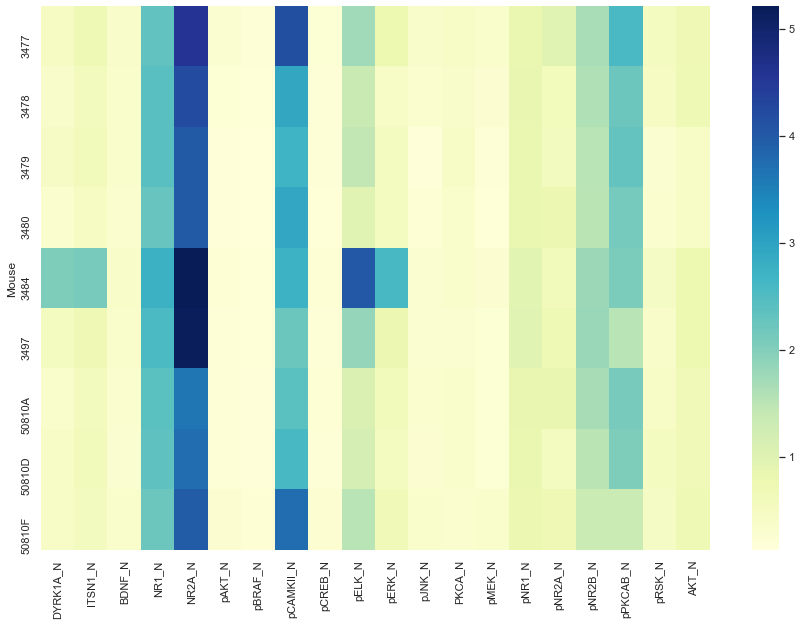

```python
import seaborn as sns

sns.heatmap(saline_expressions, cmap="YlGnBu")
```

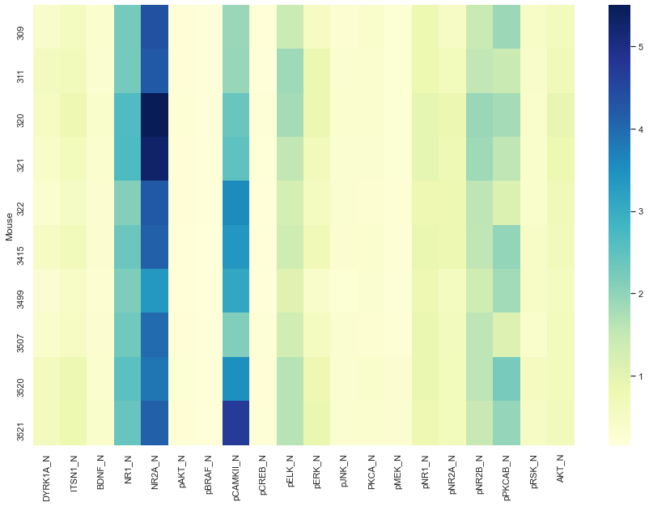

```python
sns.heatmap(memantine_expressions, cmap="YlGnBu")
```

From the heat maps, it seems that overall, expression levels for particular proteins are similar both within and between groups. However there is of course some variation. As part of our project, we want to compare the variation within and between the groups. Furthermore, particular proteins may vary in their expression more than others. Analyzing these variations may give insight into the effects of memantine, in particular on certain proteins.

Let's repeat this process controlling for a different variable -- whether or not the mouse was stimulated to learn (shocked). We will keep constant the fact that the mice are in the control group of the study (as opposed to having down syndrome), as well as the injection (saline). The classes of interest are thus c-CS-s (stimulated) and c-SC-s (not stimulated).

```python
#We already have control_stim_saline

control_notstim_saline = df_proteins[df_proteins["class"] == "c-SC-s"]

stim_mice = saline_mice
notstim_mice = list(control_notstim_saline["Mouse"].unique())

#Grab the rows from the mean_expressions DataFrame corresponding to the mice in these two classes.
stim_expressions = mean_expressions.loc[stim_mice][df_proteins.columns[:20]]
notstim_expressions = mean_expressions.loc[notstim_mice][df_proteins.columns[:20]]
```

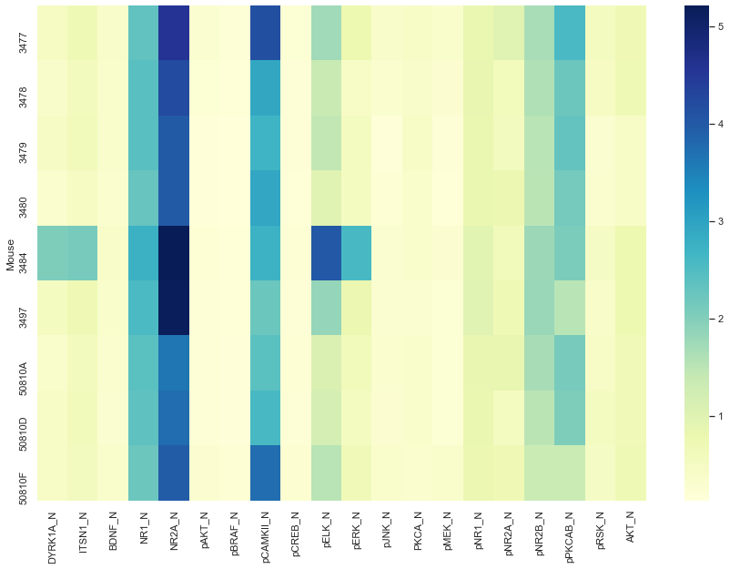

```python
sns.heatmap(stim_expressions, cmap="YlGnBu")
```

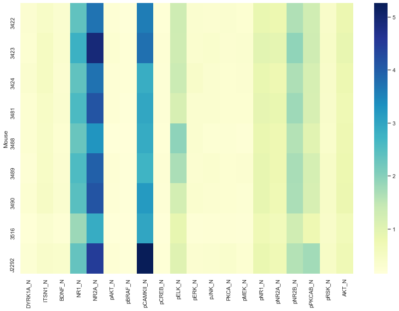

```python
sns.heatmap(notstim_expressions, cmap="YlGnBu")
```

It seems that similar conslusions to those related above can be drawn from the heatmaps of these two classes. Let's plot expressions for different classes in one four-subplot figure to allow for even easier comparison. Currently, we've only plotted three distinct classes, so I'll also generate a matrix of expression data for the c-SC-m class, which can be compared with c-SC-s, and plot the heatmap for that instead.

```python
#Yet again, use a binary mask to isolate the group "c-SC-m"
control_notstim_memantine = df_proteins[df_proteins["class"] == "c-SC-m"]
notstim_mem_mice = list(control_notstim_memantine["Mouse"].unique())

#Grab the rows from the mean_expressions DataFrame corresponding to the mice in  these two classes.
nonstim_sal_expressions = notstim_expressions #we already hve this data, so just reassign the variable
notstim_mem_expressions = mean_expressions.loc[notstim_mem_mice][df_proteins.columns[:20]]
```

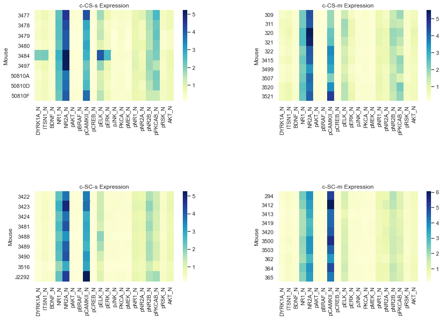

```python
#construct a matplotlib axis object with four subplots to display the four graphs
fig, axes = plt.subplots(nrows=2, ncols=2)
#make sure all the labels and titles can be seen
plt.subplots_adjust(wspace=0.4, hspace=1)

#now plot
sns.heatmap(saline_expressions, cmap="YlGnBu", ax=axes[0, 0])
axes[0, 0].set_title('c-CS-s Expression')
sns.heatmap(memantine_expressions, cmap="YlGnBu", ax=axes[0, 1])
axes[0, 1].set_title('c-CS-m Expression')
sns.heatmap(nonstim_sal_expressions, cmap="YlGnBu", ax=axes[1, 0])
axes[1, 0].set_title('c-SC-s Expression')
sns.heatmap(notstim_mem_expressions, cmap="YlGnBu", ax=axes[1, 1])
axes[1, 1].set_title('c-SC-m Expression')
```

Now we're going to take a step back in order to analyze some of the proteins. As seen in the heatmaps above, protein expression for the each protein varies slightly across each mice. To get a better feel for the protein expression per class, we are going to take an average of protein expression across all mice per class for each protein. We will then display the results in a series of heatmaps in order to find which proteins stand out. We will split the proteins between two heatmaps since there are a large number of proteins.

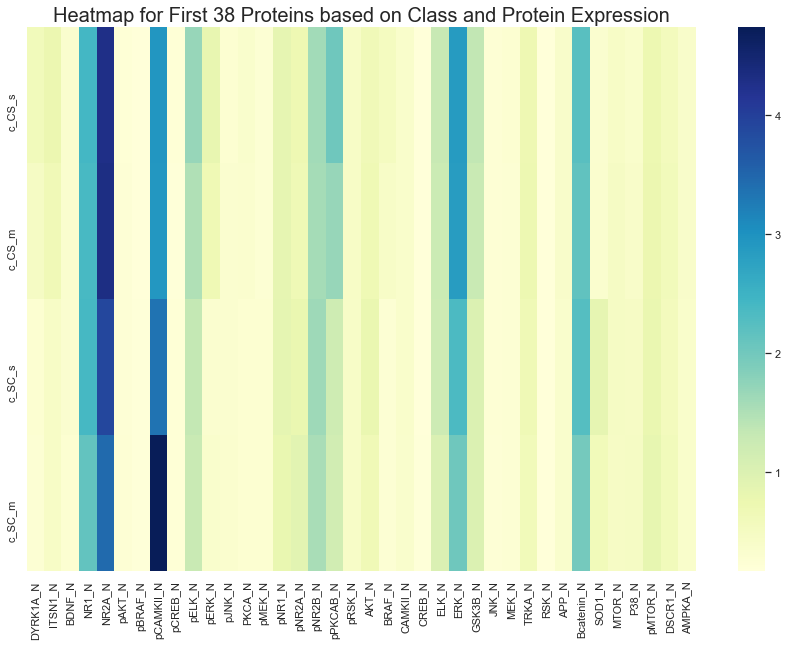

```python
# Creating dataframes for control non-stimulated learning because stimulated learning is already made

control_stim_saline = df_proteins[df_proteins["class"] == "c-CS-s"]
saline_mice_stim = list(control_stim_saline["Mouse"].unique())

control_stim_memantine = df_proteins[df_proteins["class"] == "c-CS-m"]
memantine_mice_stim = list(control_stim_memantine["Mouse"].unique())

control_nostim_saline = df_proteins[df_proteins["class"] == "c-SC-s"]
saline_mice_nostim = list(control_nostim_saline["Mouse"].unique())


control_nostim_mem = df_proteins[df_proteins["class"] == "c-SC-m"]
memantine_mice_nostim = list(control_nostim_mem["Mouse"].unique())



# c-CS-s
c_CS_s = mean_expressions.loc[saline_mice_stim][df_proteins.columns[:len(df_proteins.columns) - 2]]

# c-CS-m
c_CS_m = mean_expressions.loc[memantine_mice_stim][df_proteins.columns[:len(df_proteins.columns) - 2]]

# c-SC-s
c_SC_s = mean_expressions.loc[saline_mice_nostim][df_proteins.columns[:len(df_proteins.columns) - 2]]

# c-SC-m
c_SC_m = mean_expressions.loc[memantine_mice_nostim][df_proteins.columns[:len(df_proteins.columns) - 2]]

# Finding mean of each protein in each class
c_CS_s_MEAN = c_CS_s.mean()
c_CS_m_MEAN = c_CS_m.mean()
c_SC_s_MEAN = c_SC_s.mean()
c_SC_m_MEAN = c_SC_m.mean()


# Making into data frame
frame = {"c_CS_s": c_CS_s_MEAN, "c_CS_m": c_CS_m_MEAN, "c_SC_s": c_SC_s_MEAN, "c_SC_m": c_SC_m_MEAN}
meanControl = pd.DataFrame(frame)
meanControl1 = meanControl[:38].T
meanControl2 = meanControl[38:].T

# Plotting first 38 proteins
plt.subplots(figsize=(15,10))
plt.title("Heatmap for First 38 Proteins based on Class and Protein Expression", fontsize =20)
sns.heatmap(meanControl1, cmap="YlGnBu")
```

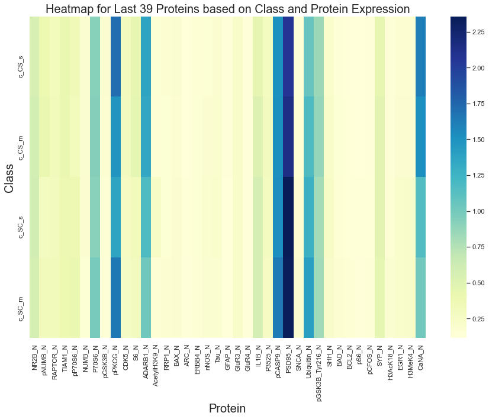

```python
# Plotting last 39 proteins
plt.subplots(figsize=(15,10))
plt.title("Heatmap for Last 39 Proteins based on Class and Protein Expression", fontsize =20)
sns.heatmap(meanControl2, cmap="YlGnBu")
plt.xlabel("Protein", fontsize = 20)
plt.ylabel("Class", fontsize = 20)
```

When analyzing these heat maps, there are some proteins that clearly show a different in expression between the classes, while some proteins have constant expression throughout all the classes. In the two heat map we have distinctive differences between classes for these 16 proteins:

- NR1_N
- NR2A_N
- pCAMKII_N
- pELK_N
- pERK_N
- pPKCAB_N
- GSK3B_N
- Bcatenin_N
- SOD1_N
- pPKCG_N
- ADARB1_N
- pCASP9_N
- PSD95_N
- pGSK3B_Tyr216_N
- Ubiquitin_N
- CaNA_N

We can make a dataframe containing these selected proteins and their average expression by class.

```python
meanControl = meanControl.reset_index()

# List of selected proteins from the heatmaps
proteinList = ["NR1_N", "NR2A_N", "pCAMKII_N", "pELK_N", "pERK_N", "pPKCAB_N", "GSK3B_N",
               "Bcatenin_N", "SOD1_N", "pPKCG_N", "ADARB1_N", "pCASP9_N", "PSD95_N",
               "pGSK3B_Tyr216_N", "Ubiquitin_N", "CaNA_N"]


proteinIndex = []
# Making list of each protein's index so we can access it later
for i in proteinList:
    index = meanControl[meanControl["index"]==i].index.values
    proteinIndex.append(int(index[0]))

# Making dataframe containing selected proteins and their mean expression for each class
proteins = meanControl.iloc[proteinIndex, :].reset_index()
proteins = proteins.set_index("index")
proteins = proteins.drop(["level_0"], axis =1)

# Displaying dataframe of average expression for selected proteins by class
proteins
```

| index | c_CS_s | c_CS_m | c_SC_s | c_SC_m |
| --- | --- | --- | --- | --- |
| NR1_N | 2.417809 | 2.381749 | 2.404974 | 2.145633 |
| NR2A_N | 4.280077 | 4.308540 | 3.913096 | 3.459416 |
| pCAMKII_N | 2.935576 | 2.916187 | 3.361288 | 4.736327 |
| pELK_N | 1.686844 | 1.492318 | 1.327714 | 1.278566 |
| pERK_N | 0.821656 | 0.690865 | 0.325854 | 0.354403 |
| pPKCAB_N | 2.028768 | 1.695686 | 1.203349 | 1.155948 |
| GSK3B_N | 1.353292 | 1.286822 | 1.013919 | 1.011697 |
| Bcatenin_N | 2.228780 | 2.150045 | 2.255591 | 1.970838 |
| SOD1_N | 0.324796 | 0.330741 | 0.856040 | 0.620829 |
| pPKCG_N | 1.714248 | 1.486330 | 1.375938 | 1.648943 |
| ADARB1_N | 1.369320 | 1.353630 | 1.174931 | 1.032217 |
| pCASP9_N | 1.507502 | 1.523643 | 1.531989 | 1.638506 |
| PSD95_N | 2.076174 | 2.141426 | 2.357227 | 2.347967 |
| pGSK3B_Tyr216_N | 0.847742 | 0.866693 | 0.811364 | 0.825483 |
| Ubiquitin_N | 1.064265 | 1.177900 | 1.271971 | 1.403618 |
| CaNA_N | 1.617609 | 1.523659 | 1.157639 | 1.009957 |

With the proteins we have determined to be most influenced by changes in the experimental variables (CS/SC and memantine/saline), we can quickly train a KNeighbors Classification (k=10) model to test whether or not these proteins truly are discriminant between the classes. The features of the model will obviously be the expressions of the proteins in "proteinList", and the model will try to predict the class (c-CS-s, c-CS-m, c-SC-s, or c-SC-m) of each mouse in the dataset.

### Classification Model

#### Define and Train Model

```python
#First, a bit of manipulation of the dataframe is necessary. We are only considering 4 out of the 8 possible
#classes in the data set, so we need to remove all irrelevant data

df_proteins = df_proteins[(df_proteins["class"] == "c-CS-s") | (df_proteins["class"] == "c-CS-m") | (df_proteins["class"] == "c-SC-s") | (df_proteins["class"] == "c-SC-m")]

df_proteins.replace([np.inf, -np.inf], np.nan, inplace=True)
df_proteins.fillna(0, inplace=True)
```

```python
from sklearn.preprocessing import StandardScaler
from sklearn.neighbors import KNeighborsClassifier

# define the training data
X_train = df_proteins[proteinList]
y_train = df_proteins["class"]

# standardize the data
scaler = StandardScaler()
scaler.fit(X_train)
X_train_sc = scaler.transform(X_train)

# fit the 10-nearest neighbors model
model = KNeighborsClassifier(n_neighbors=10)
model.fit(X_train_sc, y_train)
```

```
KNeighborsClassifier(n_neighbors=10)
```

```python
#Now train the model
y_train_pred = model.predict(X_train_sc)
```

#### Compute Metrics and Analyze Model

With the model trained, we can see how well the expressions of these particular proteins predicts the class of experimental variables that a mouse was exposed to. We will compute the average cross-validation accuracy as well as average cross-validation F1 scores for each class, as these should be sufficient to analyze the performance.

```python
from sklearn.pipeline import Pipeline
from sklearn.model_selection import cross_val_score
from sklearn.metrics import f1_score

pipeline = Pipeline([
    ("scaler", scaler),
    ("model", model)
])

#Calculate the average cross-validation accuracy
validation_accuracy = cross_val_score(pipeline, X_train, y_train,
                cv=10, scoring="accuracy").mean()
print("The validation accuracy of the model is {}".format(validation_accuracy))

#Calculate the average cross-validation F1 scores for each class

is_c_CS_s = (y_train_pred == "c-CS-s")
is_c_CS_m = (y_train_pred == "c-CS-m")
is_c_SC_s = (y_train_pred == "c-SC-s")
is_c_SC_m = (y_train_pred == "c-SC-m")


c_CS_s_f1 = cross_val_score(pipeline, X_train, is_c_CS_s,
                cv=10, scoring="f1").mean()
c_CS_m_f1 = cross_val_score(pipeline, X_train, is_c_CS_m,
                cv=10, scoring="f1").mean()
c_SC_s_f1 = cross_val_score(pipeline, X_train, is_c_SC_s,
                cv=10, scoring="f1").mean()
c_SC_m_f1 = cross_val_score(pipeline, X_train, is_c_SC_m,
                cv=10, scoring="f1").mean()

print()
print("c_CS_s F1 score: {}".format(c_CS_s_f1))
print("c_CS_m F1 score: {}".format(c_CS_m_f1))
print("c_SC_s F1 score: {}".format(c_SC_s_f1))
print("c_SC_m F1 score: {}".format(c_SC_m_f1))
```

```
The validation accuracy of the model is 0.7649122807017543

c_CS_s F1 score: 0.5576914058822302
c_CS_m F1 score: 0.7161136826912963
c_SC_s F1 score: 0.8191112973048457
c_SC_m F1 score: 0.8689814814814815
```

Overall, it seems the overall accuracy of the model is good, indicating that we picked a good set of proteins whose expressions are related most to changes in the experimental variables. There is, however, quite a bit of variation in the F1 scores for each class (c-CS-s had quite a low F1 score while c-SC-m did very well).

### A Closer Look at the most Discriminant Proteins

Now let's analyze 16 proteins from the heat map in a little more detail. By splitting the proteins into 2 groups of 8, we can make a bar graph detailing the differences in mean expression for each protein by class.

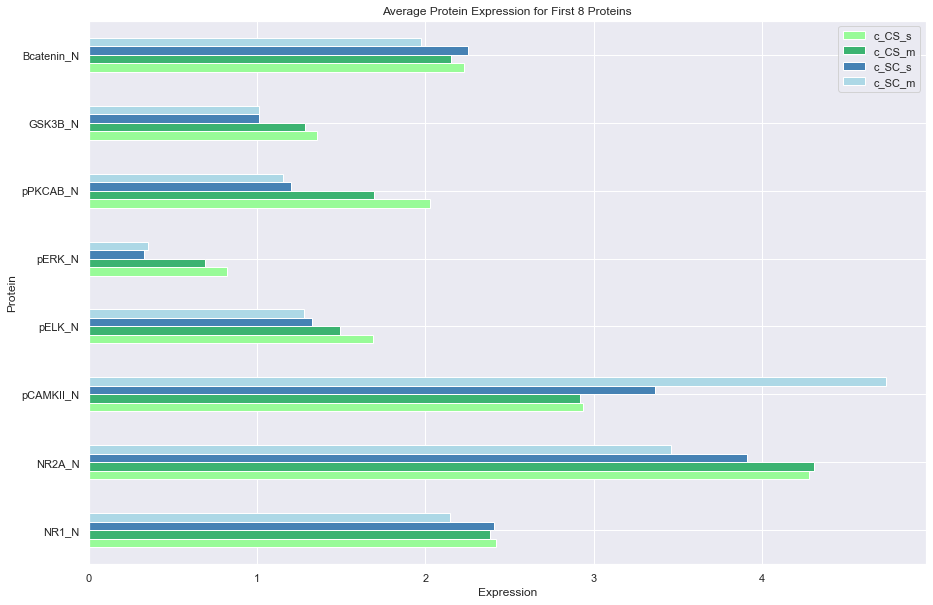

```python
# First 8 bar graph
sns.set(rc={'figure.figsize':(15,10)})
ax = proteins[:8].plot(kind='barh', title = "Average Protein Expression for First 8 Proteins",
                      color=['palegreen', 'mediumseagreen', 'steelblue', 'lightblue'])
plt.xlabel("Expression")
plt.ylabel("Protein")
```

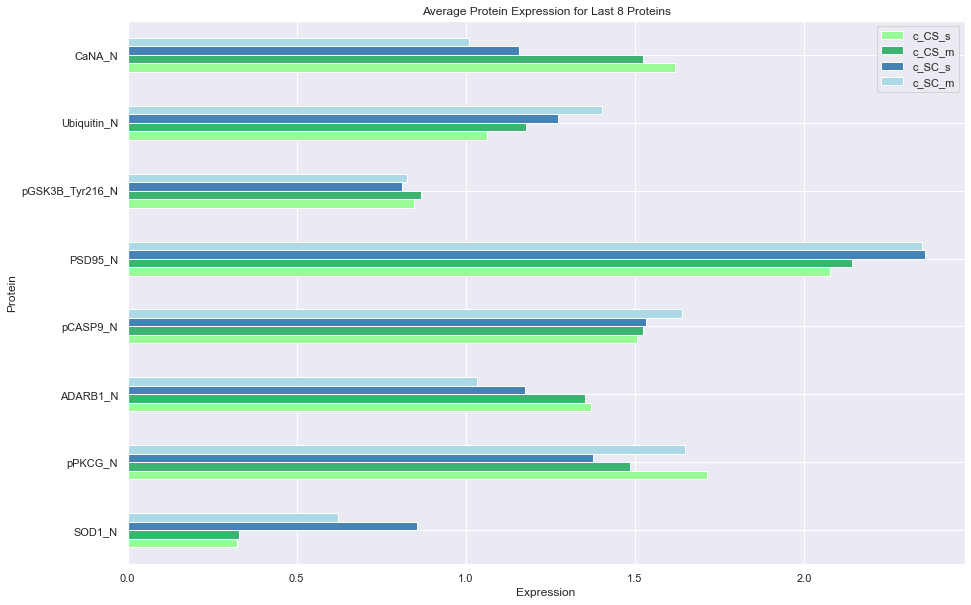

```python
# Last 8 bar graph
ax = proteins[8:].plot(kind='barh', title = "Average Protein Expression for Last 8 Proteins",
                      color=['palegreen', 'mediumseagreen', 'steelblue', 'lightblue'])
plt.xlabel("Protein Expression Level")
plt.xlabel("Expression")
plt.ylabel("Protein")
```

The bar graphs above show the expression levels of a certain selected proteins in order to directly compare the 4 classes of mice. The graphs demonstrate which proteins have varying expression levels for each class, while also showing which proteins do not have significant changes in expression between classes. From this graph we were able to choose which proteins to further research based on the varying levels expression. We chose proteins that have varying expression across the classes because it indicates that they might be affected by the experimental variables. The 12 proteins that would be ideal for further research are:

- NR2A_N
- pCAMKII_N
- pELK_N
- pERK_N
- pPKCAB_N
- GSK3B_N
- SOD1_N
- pPKCG_N
- ADARB1_N
- PSD95_N
- Ubiquitin_N
- CaNA_N

#### Further Analysis on Some of the Proteins

We have picked a few proteins to further analyze to demonstrate what we can learn from our findings and how they can stimulate lots of future research.

##### NR2A

- NR2A expression is increased in mice that are stimulated to learn (fear conditioning) compared to those who are not stimulated to learn. NR2A is a protein called glutamate receptor, ionotropic, N-methyl D-aspartate(NMDA) 2A. This protein is one of two subunits in an ionotropic NMDA receptor. It has been proven that NMDA receptors are needed for proper fear memory, so an increase in NMDA receptors would indicate proper fear memory storage. So if NR2A is increased in mice that are stimulated to learn fear, it supports evidence that an increase in NMDA receptors demonstrates proper fear memory storage, and that mice stimulated to learn fear are possibly increasing their amount of NMDA receptors to store more fear memory.
  - https://www.uniprot.org/uniprot/P35436
  - https://www.ncbi.nlm.nih.gov/pmc/articles/PMC3703758/

##### pCAMKII

- pCAMKII is more highly expressed in mice not stimulated to learn, especially in mice treated with memantine. pCAMKII is a protein named Calcium/calmodulin-dependent protein kinase type II. This protein has shown to be an important factor in learning and memory. An excerpt from an article in Nature states, "Calcium- and calmodulin-dependent protein kinase II (CaMKII) and glutamate receptors are integrally involved in forms of synaptic plasticity that may underlie learning and memory" (Bayer, KU., 2001). CAMKII is activated by Ca2+, which enters the cell through NMDA receptors. Memantine is NMDA receptor antagonist, meaning it prevents glutamate from binding to the receptor, which reduces glutamate transmission. We would hypothesize that with decreased glutamate transmission, there would be less Cat2+ to activate CAMKII, but something about a mouse being not stimulated to learn contradicts this hypothesis. Since both CAMKII and NMDA receptors are involved in memory and learning, not being stimulated to learn clearly affects CAMKII expression levels. One way this might be possible is that the mice that are not stimulated to learn likely have a decreased amount of NMDA receptors than those who are stimulated to learn. So when memantine is blocking glutamate transmission in the brain, it is at such a low level that the brain will make more NMDA receptors. So it's possible that the increased NMDA receptors greatly outnumbers the amount of memantine in the brain, so there are a large amount of unblocked NMDA receptors that are producing a Ca2+ influx, which activates a large amount of CAMKII. This is just one theory based on the information I have discovered from this dataset and some outside research, so this hypothesis would need to thoroughly investigated before any conclusions could be made. Learning about this protein and how it's affected by learning and memantine future research.
  - https://www.nature.com/articles/35081080
  - https://www.uniprot.org/uniprot/P28652
  - Bayer, KU., De Koninck, P., Leonard, A. et al. Interaction with the NMDA receptor locks CaMKII in an active conformation. Nature 411, 801–805 (2001). https://doi.org/10.1038/35081080

### Conclusion

Overall we successfully found proteins with expression levels that were affected by the experimental variables. We focused on finding the proteins that would be the most likely to change in expression level by class through our use of heatmaps, bar graphs, and our classification model. After we narrowed our data down to a list of 12 proteins, we were able to do some biological research to try and figure out why a variable was affecting a certain protein. Though we can make no conclusive answers since that would require far more experiments, we are able to confidently say that there is some research confirming our claims. The most important part about this project was that we have ended up with more questions than when we started. There are 12 or more (depending on criteria) proteins to be studied in depth, and the variables in this experiment can help explain part of their functions. There is so much opportunity for future research based on what we found in this project. To learn more about any of these proteins, the website Uniprot (https://www.uniprot.org) is a great starting place to get all sorts of information on a protein, from structure to function. We have also linked a couple of scientific articles about the proteins we spent some time researching above.